# NAVCO

Nonviolent and Violent Campaigns and Outcomes (NAVCO)

- Maximalist: goals like regime change, secession, anti-colonial, or anti-apartheid
- Campaigns: “a series of observable, continuous, purposive mass tactics or events in pursuit of a political objective.”
- With at least 1,000 participants at some point

# Unit(s) of analysis

[output not shown]

# Outcome measures

During the campaign/campaign-year/event:

- success: 100% of stated aims
- limited: some of stated aims
- failure: no goals achieved/failure (ongoing campaigns are coded as failed)

# Violence Measures

- primary tactic within the unit (campaign, campaign-year, or event)
- additional measures of intensity and scope
- CAMEO codes (version 3)

# Limitations: outcomes

- tough to define success
- case bias (failed movements get less coverage)

# Limitations: violence and non-violence

- No purely non-violent movement
- Radical flank effects

# Downloading:

NAVCO is stored on a [Harvard Dataverse](https://dataverse.harvard.edu/dataverse/navco) site. You can download it directly there, or use the dataverse R-package to access it.

```r
library(dataverse)



navco_12<-get_dataframe_by_name(filename = 'NAVCO 1.2 Updated.tab',
                             dataset = 'doi:10.7910/DVN/0UZOTX',
                            server = "dataverse.harvard.edu",
                            original=TRUE,
                            .f = readxl::read_xlsx
                             )%>%
  filter(ONGOING == 0)
```

# Recoding

Success, Limited success, and failure are mutually exclusive, but here they’re stored in separate dummy variables. But in a lot of cases we will want to combine these into a single variable.

| CAMPAIGN | SUCCESS | LIMITED | FAILURE |
| --- | --- | --- | --- |
| Afghans | 1 | 0 | 0 |
| Afghan resistance | 1 | 0 | 0 |
| Taliban/anti-government forces | 1 | 0 | 0 |
| Albanian anti-communist | 1 | 0 | 0 |
| Algerian Revolt/National Liberation Front | 1 | 0 | 0 |
| former rebel leaders | 0 | 0 | 1 |

# Recoding

We can do this using base R commands and some indexing

```r
navco_12$outcome<-NA
navco_12$outcome[navco_12$SUCCESS==1]<-"success"
navco_12$outcome[navco_12$LIMITED==1]<-"limited success"
navco_12$outcome[navco_12$FAILURE==1]<-"failure"

table(navco_12$outcome)
```

```
##
##         failure limited success         success
##             158              44             150
```

# Recoding

Note: order of operations can matter for these conditional statements. What if a want to create a separate category for ongoing campaigns?

| SUCCESS | LIMITED | FAILURE | ONGOING |
| --- | --- | --- | --- |
| 1 | 0 | 0 | 0 |
| 1 | 0 | 0 | 0 |
| 1 | 0 | 0 | 0 |
| 1 | 0 | 0 | 0 |
| 1 | 0 | 0 | 0 |
| 0 | 0 | 1 | 0 |

# Recoding

Why doesn’t this work?

```r
navco_12$outcome_4cat<-NA
navco_12$outcome_4cat[navco_12$ONGOING==1]<-"ongoing"
navco_12$outcome_4cat[navco_12$SUCCESS==1]<-"success"
navco_12$outcome_4cat[navco_12$FAILURE==1]<-"failure"
navco_12$outcome_4cat[navco_12$LIMITED==1]<-"limited success"

table(navco_12$outcome_4cat)
```

```
##
##         failure limited success         success
##             158              44             150
```

# Recoding

```r
navco_12$outcome_4cat<-NA
navco_12$outcome_4cat[navco_12$SUCCESS==1]<-"success"
navco_12$outcome_4cat[navco_12$FAILURE==1]<-"failure"
navco_12$outcome_4cat[navco_12$LIMITED==1]<-"limited success"
navco_12$outcome_4cat[navco_12$ONGOING==1]<-"ongoing"

table(navco_12$outcome_4cat)
```

```
##
##         failure limited success         success
##             158              44             150
```

# Recoding

We could also do this using [case_when](https://dplyr.tidyverse.org/reference/case_when.html) and mutate from the dplyr package. The same cautions apply, but case_when gets applied in reverse order.

```r
navco_12<-navco_12%>%
  mutate(outcome_4cat = case_when(
                             ONGOING == 1 ~ 'ongoing', #
                             SUCCESS == 1 ~ "success",
                             LIMITED == 1 ~ "limited success",
                             FAILURE == 1 ~ "failure"
                             ))

table(navco_12$outcome_4cat)
```

```
##
##         failure limited success         success
##             158              44             150
```

# Recoding

You can get pretty complicated with the conditions

```r
navco_12<-navco_12%>%
  mutate(outcome_type = case_when(
                             VIOL == 1 & REGCHANGE ==1 ~ "violent regime change",
                             VIOL == 0 & REGCHANGE ==1 ~ "non-violent regime change",
                             VIOL == 1 & REGCHANGE ==0 ~ "violent other",
                             VIOL == 0 & REGCHANGE ==0 ~ "non-violent other",

                             ))

table(navco_12$outcome_type)
```

```
##
##         non-violent other non-violent regime change             violent other
##                        26                       138                        78
##     violent regime change
##                       110
```

# Recoding

Do the same for campaign outcomes

```r
head(navco_12[,c('CAMPAIGN','REGCHANGE','FSELFDET','SECESSION', 'OTHER')])
```

```
## # A tibble: 6 × 5
##   CAMPAIGN                                  REGCHANGE FSELFDET SECESSION OTHER
##   <chr>                                         <dbl>    <dbl>     <dbl> <dbl>
## 1 Afghans                                           1        0         0     0
## 2 Afghan resistance                                 0        1         0     0
## 3 Taliban/anti-government forces                    1        0         0     0
## 4 Albanian anti-communist                           1        0         0     0
## 5 Algerian Revolt/National Liberation Front         0        1         0     0
## 6 former rebel leaders                              1        0         0     0
```

# Recoding

Doing both at the same time:

```r
navco_12 <- navco_12 %>%
  mutate(outcome  = case_when(SUCCESS == 1 ~ "success",
                              LIMITED == 1 ~ "limited success",
                              FAILURE == 1 ~ "failure"),
         goal = case_when(REGCHANGE == 1 ~ 'regime change',
                          FSELFDET == 1 ~ "self-determination",
                          SECESSION == 1 ~ "secession",
                          OTHER == 1 ~ 'other'
                          ),

         tactic = case_when(VIOL == 1 ~ "violence",
                            NONVIOL == 1 ~ "non-violence"
                            )




  )
```

# Comparing outcomes

Are non-violent movements more likely to succeed? (what else do we need here?)

```r
table(navco_12$outcome, navco_12$tactic)
```

```
##
##                   non-violence violence
##   failure                   48      110
##   limited success           22       22
##   success                   94       56
```

# Comparing outcomes

Are non-violent movements more likely to succeed? (what else do we need here?)

```r
prop.table(table(navco_12$outcome, navco_12$tactic), 2)
```

```
##
##                   non-violence  violence
##   failure            0.2926829 0.5851064
##   limited success    0.1341463 0.1170213
##   success            0.5731707 0.2978723
```

# Comparing outcomes: improving the look of the table

We can use the gtsummary package to format our table into something more appealing

```r
library(gtsummary)


navco_12 %>%
  select(outcome, tactic)%>%
  # by = independent variable
  tbl_summary(by = tactic)
```

| **Characteristic** | **non-violence**, N = 164<sup>1</sup> | **violence**, N = 188<sup>1</sup> |
| --- | --- | --- |
| outcome |  |  |
| failure | 48 (29%) | 110 (59%) |
| limited success | 22 (13%) | 22 (12%) |
| success | 94 (57%) | 56 (30%) |

<sup>1</sup> n (%)

# Comparing outcomes: using a plot

We could also show this in something like a barplot

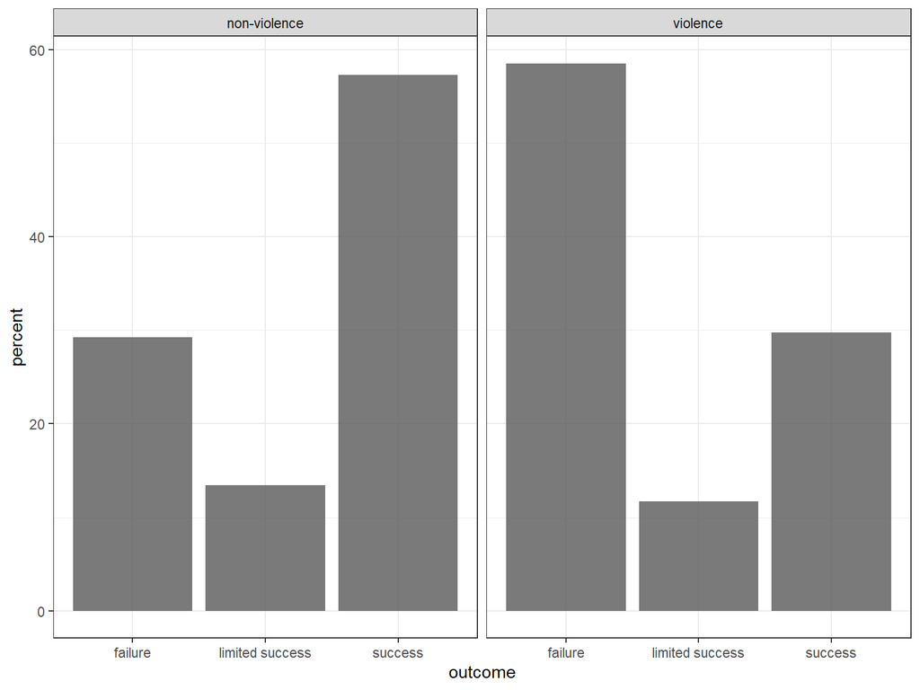

```r
navco_12%>%

  count(tactic, outcome)%>%
  ungroup()%>%
  group_by(tactic)%>%
  mutate(total = sum(n),
         percent = (n/total) * 100
         )%>%

  ggplot(aes(x= outcome, y=percent)) +
  geom_bar(stat='identity', position='dodge', alpha=.8) +
  theme_bw() +
  facet_grid(~tactic)
```

# Considering radical flanks

Do radical flanks make non-violent movements more effective?

```r
navco_12<-navco_12%>%
  mutate(tactic_3cat = case_when(`VIOLENT FLANK` == 1 ~ 'violent flank',
                                  VIOL == 1 ~ "violence",
                                  NONVIOL == 1 ~ "non-violence"))
```

# Considering Radical Flanks

```r
navco_12%>%
  select(outcome, tactic_3cat)%>%
  tbl_summary(by=tactic_3cat)
```

| **Characteristic** | **non-violence**, N = 109<sup>1</sup> | **violence**, N = 188<sup>1</sup> | **violent flank**, N = 55<sup>1</sup> |
| --- | --- | --- | --- |
| outcome |  |  |  |
| failure | 32 (29%) | 110 (59%) | 16 (29%) |
| limited success | 17 (16%) | 22 (12%) | 5 (9.1%) |
| success | 60 (55%) | 56 (30%) | 34 (62%) |

<sup>1</sup> n (%)

# Graphing it

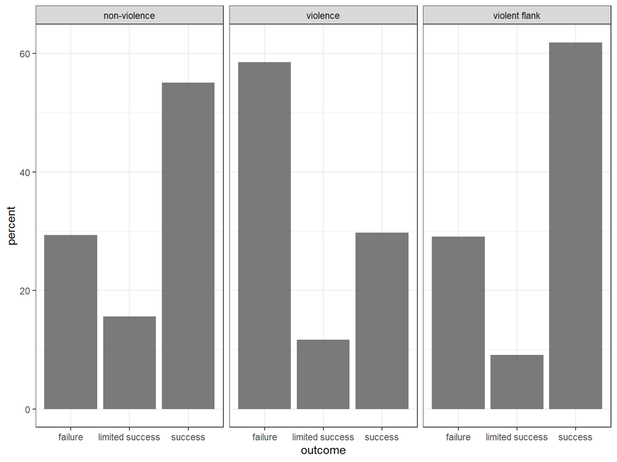

```r
navco_12%>%
  count(tactic_3cat, outcome)%>%
  group_by(tactic_3cat)%>%
  mutate(total = sum(n),
         percent = (n/total) * 100
         )%>%

  ggplot(aes(x= outcome, y=percent)) + geom_bar(stat='identity', position='stack', alpha=.8) +
  theme_bw() +
  facet_grid(~tactic_3cat)
```

# Three way table

Including a third characteristic is more complicated. If the outcome is binary (or you can recode it as binary) then one approach is to just use the mean of success across the other two dimensions.

```r
navco_12%>%
  select(goal, tactic, outcome)%>%
  tbl_strata(strata = tactic,
             .tbl_fun = ~ .x %>% tbl_summary(by=c(goal)))
```

| **Characteristic** | **non-violence** **other**, N = 4<sup>1</sup> | **non-violence** **regime change**, N = 138<sup>1</sup> | **non-violence** **secession**, N = 10<sup>1</sup> | **non-violence** **self-determination**, N = 12<sup>1</sup> | **violence** **other**, N = 4<sup>1</sup> | **violence** **regime change**, N = 110<sup>1</sup> | **violence** **secession**, N = 38<sup>1</sup> | **violence** **self-determination**, N = 36<sup>1</sup> |
| --- | --- | --- | --- | --- | --- | --- | --- | --- |
| outcome |  |  |  |  |  |  |  |  |
| failure | 1 (25%) | 35 (25%) | 8 (80%) | 4 (33%) | 4 (100%) | 66 (60%) | 27 (71%) | 13 (36%) |
| limited success | 0 (0%) | 17 (12%) | 1 (10%) | 4 (33%) | 0 (0%) | 13 (12%) | 7 (18%) | 2 (5.6%) |
| success | 3 (75%) | 86 (62%) | 1 (10%) | 4 (33%) | 0 (0%) | 31 (28%) | 4 (11%) | 21 (58%) |

<sup>1</sup> n (%)

# Three way table

Another approach: just filter the categories and make separate tables for each

```r
navco_12%>%
  filter(goal =="regime change")%>%
  select(outcome, tactic)%>%
  tbl_summary(by = tactic)
```

| **Characteristic** | **non-violence**, N = 138<sup>1</sup> | **violence**, N = 110<sup>1</sup> |
| --- | --- | --- |
| outcome |  |  |
| failure | 35 (25%) | 66 (60%) |
| limited success | 17 (12%) | 13 (12%) |
| success | 86 (62%) | 31 (28%) |

<sup>1</sup> n (%)

```r
navco_12%>%
  filter(goal =="secession")%>%
  select(outcome, tactic)%>%
  tbl_summary(by=tactic)
```

| **Characteristic** | **non-violence**, N = 10<sup>1</sup> | **violence**, N = 38<sup>1</sup> |
| --- | --- | --- |
| outcome |  |  |
| failure | 8 (80%) | 27 (71%) |
| limited success | 1 (10%) | 7 (18%) |
| success | 1 (10%) | 4 (11%) |

<sup>1</sup> n (%)

# Three way table

Another option: use base R commands and then export to a spreadsheet of your choice for reformatting.

```r
with(navco_12,
     # ftable creates three way tables
     ftable(outcome, tactic, goal))%>%
  # proportion along dimension 2 (columns)
  prop.table(., 2)
```

```
##                              goal      other regime change  secession self-determination
## outcome         tactic
## failure         non-violence      0.12500000    0.14112903 0.16666667         0.08333333
##                 violence          0.50000000    0.26612903 0.56250000         0.27083333
## limited success non-violence      0.00000000    0.06854839 0.02083333         0.08333333
##                 violence          0.00000000    0.05241935 0.14583333         0.04166667
## success         non-violence      0.37500000    0.34677419 0.02083333         0.08333333
##                 violence          0.00000000    0.12500000 0.08333333         0.43750000
```

# Role of External Support

Use the NAVCO 1.2 codebook to find the measure for external state support. Does it impact outcomes?

# Role of External Support

Use the NAVCO 1.2 codebook to find the measure for external state support. See if it impacts movement outcomes.

# Role of External Support

Does the use of violence increase or decrease the likelihood of state support?

# Role of External Support

Does the use of violence increase or decrease the likelihood of state support?

```r
navco_12%>%
  select(STATESUP, tactic)%>%
  mutate(STATESUP = factor(STATESUP, labels=c("No state support", "State support")))%>%
  tbl_summary(by=tactic)
```

| **Characteristic** | **non-violence**, N = 164<sup>1</sup> | **violence**, N = 188<sup>1</sup> |
| --- | --- | --- |
| STATESUP |  |  |
| No state support | 151 (92%) | 110 (59%) |
| State support | 13 (7.9%) | 78 (41%) |

<sup>1</sup> n (%)

# Movement duration

Histograms or boxplots work well for describing a single continuous variable.

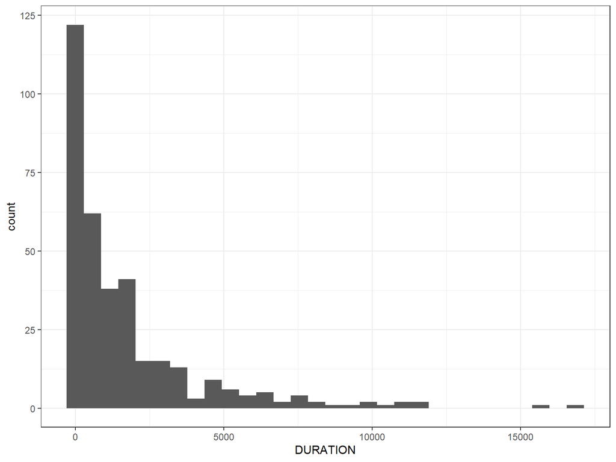

```r
navco_12%>%
  mutate(DURATION = as.numeric(DURATION))%>%
  ggplot(aes(x = DURATION)) +
  geom_histogram() +
  theme_bw()
```

# Movement duration

…although a boxplot may look a bit funky here

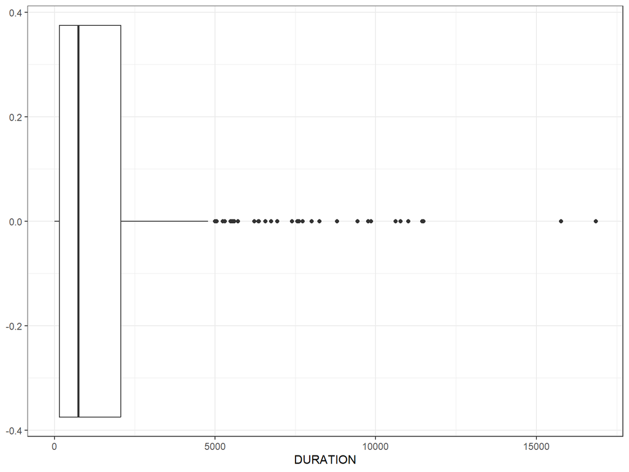

```r
navco_12%>%
  mutate(DURATION = as.numeric(DURATION))%>%
  ggplot(aes(x = DURATION)) +
  geom_boxplot() +
  theme_bw()
```

# Movement Duration

Does external support have any impact on movement duration?

# Summary stats

The gtsummary packages can produce nicely formatted tables of multiple descriptive stats without much effort.

```r
navco_12%>%
    mutate(DURATION = as.numeric(DURATION))%>%
  select(goal, tactic, outcome, DURATION)%>%
  tbl_summary()
```

| **Characteristic** | **N = 352**<sup>1</sup> |
| --- | --- |
| goal |  |
| other | 8 (2.3%) |
| regime change | 248 (70%) |
| secession | 48 (14%) |
| self-determination | 48 (14%) |
| tactic |  |
| non-violence | 164 (47%) |
| violence | 188 (53%) |
| outcome |  |
| failure | 158 (45%) |
| limited success | 44 (13%) |
| success | 150 (43%) |
| DURATION | 739 (152, 2,066) |

<sup>1</sup> n (%); Median (IQR)

# Summary stats

```r
navco_12%>%
  mutate(DURATION = as.numeric(DURATION))%>%

  select(goal, outcome, tactic, PARTICIPATION, DURATION)%>%
  tbl_summary(by =tactic)%>%
  add_p()
```

| **Characteristic** | **non-violence**, N = 164<sup>1</sup> | **violence**, N = 188<sup>1</sup> | **p-value**<sup>2</sup> |
| --- | --- | --- | --- |
| goal |  |  | <0.001 |
| other | 4 (2.4%) | 4 (2.1%) |  |
| regime change | 138 (84%) | 110 (59%) |  |
| secession | 10 (6.1%) | 38 (20%) |  |
| self-determination | 12 (7.3%) | 36 (19%) |  |
| outcome |  |  | <0.001 |
| failure | 48 (29%) | 110 (59%) |  |
| limited success | 22 (13%) | 22 (12%) |  |
| success | 94 (57%) | 56 (30%) |  |
| PARTICIPATION | 70,000 (10,000, 200,000) | 10,000 (3,000, 23,250) | <0.001 |
| Unknown | 5 | 4 |  |
| DURATION | 324 (59, 927) | 1,608 (339, 3,625) | <0.001 |

<sup>1</sup> n (%); Median (IQR)  
<sup>2</sup> Fisher’s exact test; Pearson’s Chi-squared test; Wilcoxon rank sum test